# Student Performance Regression Analysis

## Convex Optimization — Partial Exam 2, Problem 4

### ITESO, Universidad Jesuita de Guadalajara

This notebook performs:

- **(a)** Ordinary Least Squares (OLS) regression
- **(b)** Ridge regression with optimal regularization parameter (L2)
- **(c)** LASSO regression with optimal regularization parameter (L1)
- **(d)** Comparative analysis and discussion of regularization effects

## 0. Imports and Setup

```python
import numpy as np
import pandas as pd
import matplotlib.pyplot as plt

from sklearn.model_selection import train_test_split, cross_val_score, KFold
from sklearn.linear_model import LinearRegression, Ridge, Lasso, RidgeCV, LassoCV
from sklearn.preprocessing import StandardScaler
from sklearn.metrics import mean_squared_error, r2_score, mean_absolute_error

%matplotlib inline
plt.rcParams['figure.figsize'] = (10, 6)
plt.rcParams['font.size'] = 12
```

## 1. Load and Explore the Dataset

```python
df = pd.read_excel('Student_performance_dataset.xlsx')
print(f"Dataset shape: {df.shape}")
df.head(10)
```

```
Dataset shape: (100, 7)
```

|  | Hours Studied | Previous Scores | Extra Activities | Sleep Hours | Counseling hours | Party-time | Performance |
| --- | --- | --- | --- | --- | --- | --- | --- |
| 0 | 9 | 10 | YES | 8 | 9 | 0 | 98.6 |
| 1 | 8 | 6 | YES | 7 | 2 | 5 | 78.4 |
| 2 | 8 | 6 | YES | 7 | 6 | 4 | 81.6 |
| 3 | 5 | 2 | NO | 1 | 3 | 1 | 37.6 |
| 4 | 6 | 2 | NO | 8 | 9 | 4 | 74.0 |
| 5 | 7 | 9 | YES | 5 | 6 | 0 | 72.6 |
| 6 | 4 | 4 | NO | 7 | 6 | 3 | 56.2 |
| 7 | 2 | 4 | YES | 2 | 4 | 0 | 28.6 |
| 8 | 8 | 2 | NO | 3 | 6 | 2 | 66.6 |
| 9 | 2 | 8 | YES | 4 | 1 | 1 | 33.6 |

```python
df.describe()
```

|  | Hours Studied | Previous Scores | Sleep Hours | Counseling hours | Party-time | Performance |
| --- | --- | --- | --- | --- | --- | --- |
| count | 100.000000 | 100.000000 | 100.000000 | 100.000000 | 100.000000 | 100.000000 |
| mean | 4.410000 | 5.230000 | 4.840000 | 4.300000 | 2.460000 | 50.758000 |
| std | 2.704635 | 2.866931 | 2.627439 | 3.040136 | 1.713995 | 19.712177 |
| min | 0.000000 | 1.000000 | 1.000000 | 0.000000 | 0.000000 | 10.200000 |
| 25% | 2.000000 | 3.000000 | 2.000000 | 2.000000 | 1.000000 | 37.000000 |
| 50% | 4.000000 | 5.000000 | 5.000000 | 4.000000 | 2.000000 | 50.200000 |
| 75% | 6.250000 | 8.000000 | 7.250000 | 7.000000 | 4.000000 | 65.150000 |
| max | 9.000000 | 10.000000 | 8.000000 | 9.000000 | 5.000000 | 98.600000 |

```python
df.info()
print(f"\nMissing values:\n{df.isnull().sum()}")
print(f"\nExtra Activities unique values: {df['Extra Activities'].unique()}")
```

```
<class 'pandas.DataFrame'>
RangeIndex: 100 entries, 0 to 99
Data columns (total 7 columns):
 #   Column            Non-Null Count  Dtype
---  ------            --------------  -----
 0   Hours Studied     100 non-null    int64
 1   Previous Scores   100 non-null    int64
 2   Extra Activities  100 non-null    str
 3   Sleep Hours       100 non-null    int64
 4   Counseling hours  100 non-null    int64
 5   Party-time        100 non-null    int64
 6   Performance       100 non-null    float64
dtypes: float64(1), int64(5), str(1)
memory usage: 5.6 KB

Missing values:
Hours Studied       0
Previous Scores     0
Extra Activities    0
Sleep Hours         0
Counseling hours    0
Party-time          0
Performance         0
dtype: int64

Extra Activities unique values: <StringArray>
['YES', 'NO']
Length: 2, dtype: str
```

## 2. Data Preparation

We need to:

1. Encode the categorical variable `Extra Activities` (YES → 1, NO → 0)
2. Split into training (80%) and testing (20%) sets
3. Standardize features (critical for Ridge and LASSO so that the penalty treats all features equally)

```python
# Encode categorical variable
df['Extra Activities'] = df['Extra Activities'].map({'YES': 1, 'NO': 0})

# Define features and target
feature_names = ['Hours Studied', 'Previous Scores', 'Extra Activities',
                 'Sleep Hours', 'Counseling hours', 'Party-time']
X = df[feature_names].values
y = df['Performance'].values

# Train-test split (80/20)
X_train, X_test, y_train, y_test = train_test_split(
    X, y, test_size=0.2, random_state=42
)

print(f"Training set size: {X_train.shape[0]} samples")
print(f"Testing set size:  {X_test.shape[0]} samples")

# Standardize features
scaler = StandardScaler()
X_train_scaled = scaler.fit_transform(X_train)
X_test_scaled = scaler.transform(X_test)

# Cross-validation setup
kf = KFold(n_splits=5, shuffle=True, random_state=42)
```

```
Training set size: 80 samples
Testing set size:  20 samples
```

```python
# Helper function
def print_metrics(name, y_true, y_pred, y_train_true=None, y_train_pred=None):
    print(f"--- {name} ---")
    if y_train_true is not None:
        print(f"  Train R²:   {r2_score(y_train_true, y_train_pred):.4f}")
        print(f"  Train RMSE: {np.sqrt(mean_squared_error(y_train_true, y_train_pred)):.4f}")
    print(f"  Test R²:    {r2_score(y_true, y_pred):.4f}")
    print(f"  Test RMSE:  {np.sqrt(mean_squared_error(y_true, y_pred)):.4f}")
    print(f"  Test MAE:   {mean_absolute_error(y_true, y_pred):.4f}")
```

## a) Ordinary Least Squares (OLS) Regression

OLS minimizes the sum of squared residuals without any regularization:

$$\hat{\boldsymbol{\beta}}_{OLS} = \arg\min_{\boldsymbol{\beta}} \|\mathbf{y} - \mathbf{X}\boldsymbol{\beta}\|^2$$

The closed-form solution is:

$$\hat{\boldsymbol{\beta}}_{OLS} = (\mathbf{X}^T\mathbf{X})^{-1}\mathbf{X}^T\mathbf{y}$$

```python
# Fit OLS model
ols_model = LinearRegression()
ols_model.fit(X_train_scaled, y_train)

y_train_pred_ols = ols_model.predict(X_train_scaled)
y_test_pred_ols = ols_model.predict(X_test_scaled)

print(f"Intercept: {ols_model.intercept_:.4f}\n")
print("Coefficients (standardized features):")
for name, coef in zip(feature_names, ols_model.coef_):
    print(f"  {name:25s}: {coef:+.4f}")

print()
print_metrics("OLS", y_test, y_test_pred_ols, y_train, y_train_pred_ols)

# Cross-validation
cv_scores_ols = cross_val_score(LinearRegression(), X_train_scaled, y_train, cv=kf, scoring='r2')
print(f"\n  5-Fold CV R² (mean ± std): {cv_scores_ols.mean():.4f} ± {cv_scores_ols.std():.4f}")
```

```
Intercept: 49.6300

Coefficients (standardized features):
  Hours Studied            : +15.9065
  Previous Scores          : +0.4771
  Extra Activities         : +0.8961
  Sleep Hours              : +9.6584
  Counseling hours         : +2.3392
  Party-time               : -1.6069

--- OLS ---
  Train R²:   0.9984
  Train RMSE: 0.7478
  Test R²:    0.9983
  Test RMSE:  0.9430
  Test MAE:   0.8598

  5-Fold CV R² (mean ± std): 0.9979 ± 0.0005
```

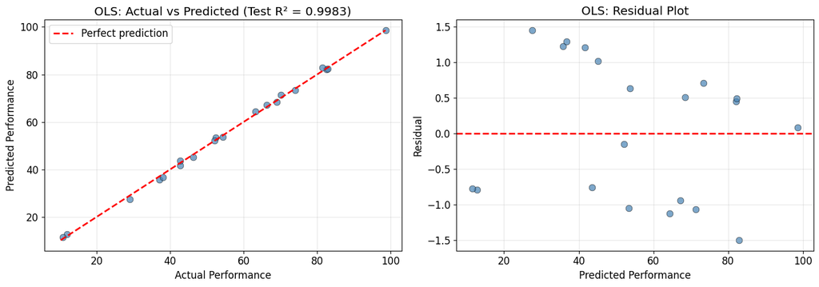

```python
# OLS: Actual vs Predicted
fig, axes = plt.subplots(1, 2, figsize=(14, 5))

axes[0].scatter(y_test, y_test_pred_ols, alpha=0.7, edgecolors='k', linewidths=0.5, color='steelblue', s=60)
axes[0].plot([y.min(), y.max()], [y.min(), y.max()], 'r--', lw=2, label='Perfect prediction')
axes[0].set_xlabel('Actual Performance')
axes[0].set_ylabel('Predicted Performance')
axes[0].set_title(f'OLS: Actual vs Predicted (Test R² = {r2_score(y_test, y_test_pred_ols):.4f})')
axes[0].legend()
axes[0].grid(True, alpha=0.3)

# OLS residuals
residuals = y_test - y_test_pred_ols
axes[1].scatter(y_test_pred_ols, residuals, alpha=0.7, edgecolors='k', linewidths=0.5, color='steelblue', s=60)
axes[1].axhline(0, color='r', linestyle='--', lw=2)
axes[1].set_xlabel('Predicted Performance')
axes[1].set_ylabel('Residual')
axes[1].set_title('OLS: Residual Plot')
axes[1].grid(True, alpha=0.3)

plt.tight_layout()
plt.show()
```

## b) Ridge Regression (L2 Regularization)

Ridge regression adds an L2 penalty to the OLS objective:

$$\hat{\boldsymbol{\beta}}_{Ridge} = \arg\min_{\boldsymbol{\beta}} \|\mathbf{y} - \mathbf{X}\boldsymbol{\beta}\|^2 + \alpha \|\boldsymbol{\beta}\|_2^2$$

The closed-form solution is:

$$\hat{\boldsymbol{\beta}}_{Ridge} = (\mathbf{X}^T\mathbf{X} + \alpha \mathbf{I})^{-1}\mathbf{X}^T\mathbf{y}$$

**Key properties:**

- Shrinks all coefficients toward zero but never exactly to zero
- Handles multicollinearity by adding $\alpha \mathbf{I}$ to the Gram matrix
- The regularization parameter $\alpha$ controls the trade-off between fit and complexity

```python
# Search for optimal alpha via cross-validation
alphas_ridge = np.logspace(-4, 4, 200)

ridge_cv = RidgeCV(alphas=alphas_ridge, cv=kf, scoring='r2')
ridge_cv.fit(X_train_scaled, y_train)
best_alpha_ridge = ridge_cv.alpha_

print(f"Optimal alpha (λ): {best_alpha_ridge:.6f}")

# Fit Ridge with optimal alpha
ridge_model = Ridge(alpha=best_alpha_ridge)
ridge_model.fit(X_train_scaled, y_train)

y_train_pred_ridge = ridge_model.predict(X_train_scaled)
y_test_pred_ridge = ridge_model.predict(X_test_scaled)

print(f"Intercept: {ridge_model.intercept_:.4f}\n")
print("Coefficients (standardized features):")
for name, coef in zip(feature_names, ridge_model.coef_):
    print(f"  {name:25s}: {coef:+.4f}")

print()
print_metrics("Ridge", y_test, y_test_pred_ridge, y_train, y_train_pred_ridge)

cv_scores_ridge = cross_val_score(
    Ridge(alpha=best_alpha_ridge), X_train_scaled, y_train, cv=kf, scoring='r2'
)
print(f"\n  5-Fold CV R² (mean ± std): {cv_scores_ridge.mean():.4f} ± {cv_scores_ridge.std():.4f}")
```

```
Optimal alpha (λ): 0.000100
Intercept: 49.6300

Coefficients (standardized features):
  Hours Studied            : +15.9065
  Previous Scores          : +0.4771
  Extra Activities         : +0.8961
  Sleep Hours              : +9.6584
  Counseling hours         : +2.3392
  Party-time               : -1.6069

--- Ridge ---
  Train R²:   0.9984
  Train RMSE: 0.7478
  Test R²:    0.9983
  Test RMSE:  0.9430
  Test MAE:   0.8598

  5-Fold CV R² (mean ± std): 0.9979 ± 0.0005
```

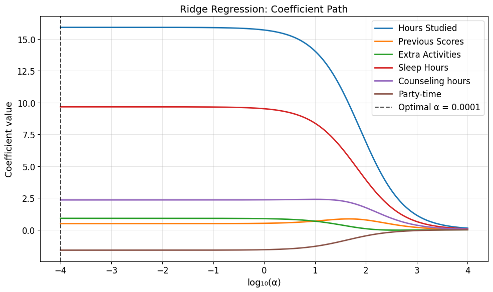

```python
# Ridge coefficient path
ridge_coefs = []
for a in alphas_ridge:
    ridge_temp = Ridge(alpha=a)
    ridge_temp.fit(X_train_scaled, y_train)
    ridge_coefs.append(ridge_temp.coef_)
ridge_coefs = np.array(ridge_coefs)

plt.figure(figsize=(10, 6))
for i, name in enumerate(feature_names):
    plt.plot(np.log10(alphas_ridge), ridge_coefs[:, i], label=name, linewidth=2)
plt.axvline(np.log10(best_alpha_ridge), color='k', linestyle='--', alpha=0.7,
            label=f'Optimal α = {best_alpha_ridge:.4f}')
plt.xlabel('log₁₀(α)', fontsize=13)
plt.ylabel('Coefficient value', fontsize=13)
plt.title('Ridge Regression: Coefficient Path', fontsize=14)
plt.legend(loc='upper right')
plt.grid(True, alpha=0.3)
plt.tight_layout()
plt.show()
```

## c) LASSO Regression (L1 Regularization)

### What is LASSO?

**LASSO** (Least Absolute Shrinkage and Selection Operator) adds an L1 penalty:

$$\hat{\boldsymbol{\beta}}_{LASSO} = \arg\min_{\boldsymbol{\beta}} \|\mathbf{y} - \mathbf{X}\boldsymbol{\beta}\|^2 + \alpha \sum_{j=1}^{p} |\beta_j|$$

**Key properties:**

- The L1 penalty creates a **non-differentiable** objective at $\beta_j = 0$
- This causes some coefficients to become **exactly zero**, performing **automatic feature selection**
- Produces **sparse models** that are easier to interpret
- Particularly useful when only a subset of features are truly relevant
- Unlike Ridge, there is **no closed-form solution**; it is solved via coordinate descent or subgradient methods
- From a convex optimization perspective, the L1 penalty is convex but not strictly convex, which leads to the sparsity-inducing property

```python
# Search for optimal alpha via cross-validation
alphas_lasso = np.logspace(-4, 2, 200)

lasso_cv = LassoCV(alphas=alphas_lasso, cv=kf, random_state=42, max_iter=10000)
lasso_cv.fit(X_train_scaled, y_train)
best_alpha_lasso = lasso_cv.alpha_

print(f"Optimal alpha (λ): {best_alpha_lasso:.6f}")

# Fit LASSO with optimal alpha
lasso_model = Lasso(alpha=best_alpha_lasso, max_iter=10000)
lasso_model.fit(X_train_scaled, y_train)

y_train_pred_lasso = lasso_model.predict(X_train_scaled)
y_test_pred_lasso = lasso_model.predict(X_test_scaled)

print(f"Intercept: {lasso_model.intercept_:.4f}\n")
print("Coefficients (standardized features):")
for name, coef in zip(feature_names, lasso_model.coef_):
    marker = " ← ZEROED OUT" if abs(coef) < 1e-6 else ""
    print(f"  {name:25s}: {coef:+.4f}{marker}")

n_nonzero = np.sum(np.abs(lasso_model.coef_) > 1e-6)
print(f"\nNon-zero coefficients: {n_nonzero}/{len(feature_names)}")

print()
print_metrics("LASSO", y_test, y_test_pred_lasso, y_train, y_train_pred_lasso)

cv_scores_lasso = cross_val_score(
    Lasso(alpha=best_alpha_lasso, max_iter=10000), X_train_scaled, y_train,
    cv=kf, scoring='r2'
)
print(f"\n  5-Fold CV R² (mean ± std): {cv_scores_lasso.mean():.4f} ± {cv_scores_lasso.std():.4f}")
```

```
Optimal alpha (λ): 0.000141
Intercept: 49.6300

Coefficients (standardized features):
  Hours Studied            : +15.9064
  Previous Scores          : +0.4770
  Extra Activities         : +0.8959
  Sleep Hours              : +9.6583
  Counseling hours         : +2.3391
  Party-time               : -1.6067

Non-zero coefficients: 6/6

--- LASSO ---
  Train R²:   0.9984
  Train RMSE: 0.7478
  Test R²:    0.9983
  Test RMSE:  0.9430
  Test MAE:   0.8599

  5-Fold CV R² (mean ± std): 0.9979 ± 0.0005
```

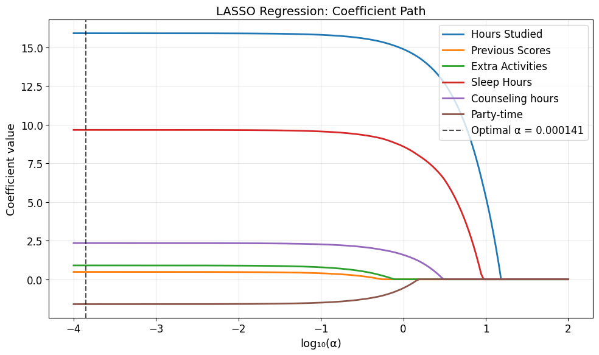

```python
# LASSO coefficient path
lasso_coefs = []
for a in alphas_lasso:
    lasso_temp = Lasso(alpha=a, max_iter=10000)
    lasso_temp.fit(X_train_scaled, y_train)
    lasso_coefs.append(lasso_temp.coef_)
lasso_coefs = np.array(lasso_coefs)

plt.figure(figsize=(10, 6))
for i, name in enumerate(feature_names):
    plt.plot(np.log10(alphas_lasso), lasso_coefs[:, i], label=name, linewidth=2)
plt.axvline(np.log10(best_alpha_lasso), color='k', linestyle='--', alpha=0.7,
            label=f'Optimal α = {best_alpha_lasso:.6f}')
plt.xlabel('log₁₀(α)', fontsize=13)
plt.ylabel('Coefficient value', fontsize=13)
plt.title('LASSO Regression: Coefficient Path', fontsize=14)
plt.legend(loc='upper right')
plt.grid(True, alpha=0.3)
plt.tight_layout()
plt.show()
```